# Lab 7: Inference and Global Climate Change

By the end of this lab, you should know how to:

1. Test whether observed data appears to be a random sample from a distribution.
2. Analyze a natural experiment.
3. Implement and interpret a sign test.
4. Create a function to run a general hypothesis test.
5. Analyze visualizations and draw conclusions from them.

```python
name = "Hannah"
name
```

```
'Hannah'
```

```python
## import statements
# These lines load the tests.
from gofer.ok import check

import numpy as np
from datascience import *
import pandas as pd
import matplotlib
%matplotlib inline
import matplotlib.pyplot as plt
plt.style.use('fivethirtyeight')
# Fix for datascience plots
import collections as collections
import collections.abc as abc
collections.Iterable = abc.Iterable
```

## Overview

Climate change is usually referring to the general trend of warming temperatures globally. Along with these increasing temperatures, unusual shifts in trends in weather activity such as hurricanes, storms, winds, etc are also usually classified under climate change. While the climate can shift due to natural occurrences, scientists have found that human interventions have potentially caused the trend of warming. One explanation for the warming could be increased solar solar activity, however scientists have found that solar activity has not generally increased during the period when temperature has increased.

[figure not shown]

Links: [NASA](https://climate.nasa.gov/causes/) [Canada](https://www.canada.ca/en/environment-climate-change/services/climate-change/causes.html)

### Data

While there's several different metrics we could analyze to make some inferences about overall trends in global climate change, for simplicity's sake we will be focusing on land temperature across different countries. The original table came from this [database](https://github.com/OpenFloodAI/Climate-Change-Datasets), however it's been reformatted to make the downstream analyses easier. There are 15 columns: Year, Country, Average Temperature of that country in that year 'avg', and then a column for each month of that year with temperatures.

```python
temps = Table.read_table('temp_per_country.csv')
temps
```

| year | country | avg | jan | feb | mar | apr | may | jun | jul | aug | sep | oct | nov | dec |
| --- | --- | --- | --- | --- | --- | --- | --- | --- | --- | --- | --- | --- | --- | --- |
| 1753 | Åland | 5.11833 | -2.412 | -3.273 | 0.71 | 2.778 | 6.226 | 11.102 | 15.159 | 15.786 | 12.106 | 8.756 | 2.248 | -7.766 |
| 1753 | Albania | 12.557 | 1.4 | 2.655 | 8.505 | 11.541 | 16.642 | 22.098 | 23.532 | 21.77 | 18.7 | 13.661 | 7.593 | 2.587 |
| 1753 | Andorra | 11.2345 | 0.938 | 4.083 | 8.352 | 9.165 | 13.783 | 19.796 | 21.148 | 18.796 | 16.546 | 11.706 | 5.991 | 4.51 |
| 1753 | Austria | 6.13892 | -6.398 | -3.537 | 2.681 | 6.498 | 11.331 | 16.209 | 16.881 | 14.751 | 12.34 | 7.072 | -0.011 | -4.15 |
| 1753 | Belarus | 5.65175 | -7.122 | -6.956 | 0.706 | 6.768 | 13.06 | 16.615 | 18.032 | 16.501 | 12.448 | 6.84 | 0.024 | -9.095 |
| 1753 | Belgium | 9.45708 | -1.215 | 2.443 | 6.838 | 8.826 | 13.042 | 17.602 | 18.072 | 16.203 | 14.761 | 10.332 | 4.143 | 2.438 |
| 1753 | Bosnia And Herzegovina | 10.3656 | -1.973 | 0.043 | 6.558 | 10.293 | 15.253 | 20.463 | 21.589 | 19.567 | 16.607 | 11.343 | 4.776 | -0.132 |
| 1753 | Bulgaria | 10.3995 | -1.841 | -0.883 | 5.889 | 10.043 | 15.723 | 20.69 | 22.084 | 20.446 | 17.03 | 11.668 | 5.201 | -1.256 |
| 1753 | Croatia | 11.2875 | -1.311 | 1.012 | 7.5 | 11.318 | 16.33 | 21.666 | 22.721 | 20.52 | 17.527 | 12.113 | 5.342 | 0.712 |
| 1753 | Czech Republic | 7.49492 | -4.72 | -2.339 | 3.956 | 8.117 | 12.84 | 17.184 | 18.175 | 16.392 | 13.701 | 8.464 | 1.475 | -3.306 |

... (44320 rows omitted)

**Question 1:** Let's explore this data a bit. The cell below creates a pivot table with years as the rows and each country as a new column. Select two countries from our dataset and draw a line plot of the changes in temperature over time. You only want to graph the years that have data for both your countries of interest (Hint: You may want to utilize where and are.above() to select those years with data). There is not a autocheck for this question as you all may have different answers depending on the countres you pick.

```python
np.unique(temps['country'])
```

```
array(['Afghanistan', 'Africa', 'Albania', 'Algeria', 'American Samoa',
       'Andorra', 'Angola', 'Anguilla', 'Antigua And Barbuda', 'Argentina',
       'Armenia', 'Aruba', 'Asia', 'Australia', 'Austria', 'Azerbaijan',
       'Bahamas', 'Bahrain', 'Baker Island', 'Bangladesh', 'Barbados',
       'Belarus', 'Belgium', 'Belize', 'Benin', 'Bhutan', 'Bolivia',
       'Bonaire, Saint Eustatius And Saba', 'Bosnia And Herzegovina',
       'Botswana', 'Brazil', 'British Virgin Islands', 'Bulgaria',
       'Burkina Faso', 'Burma', 'Burundi', 'Cambodia', 'Cameroon',
       'Canada', 'Cape Verde', 'Cayman Islands',
       'Central African Republic', 'Chad', 'Chile', 'China',
       'Christmas Island', 'Colombia', 'Comoros', 'Congo',
       'Congo (Democratic Republic Of The)', 'Costa Rica', 'Croatia',
       'Cuba', 'Curaçao', 'Cyprus', 'Czech Republic', "Côte D'Ivoire",
       'Denmark', 'Denmark (Europe)', 'Djibouti', 'Dominica',
       'Dominican Republic', 'Ecuador', 'Egypt', 'El Salvador',
       'Equatorial Guinea', 'Eritrea', 'Estonia', 'Ethiopia', 'Europe',
       'Falkland Islands (Islas Malvinas)', 'Faroe Islands',
       'Federated States Of Micronesia', 'Fiji', 'Finland', 'France',
       'France (Europe)', 'French Guiana', 'French Polynesia',
       'French Southern And Antarctic Lands', 'Gabon', 'Gambia',
       'Gaza Strip', 'Georgia', 'Germany', 'Ghana', 'Greece', 'Greenland',
       'Grenada', 'Guadeloupe', 'Guam', 'Guatemala', 'Guernsey', 'Guinea',
       'Guinea Bissau', 'Guyana', 'Haiti',
       'Heard Island And Mcdonald Islands', 'Honduras', 'Hong Kong',
       'Hungary', 'Iceland', 'India', 'Indonesia', 'Iran', 'Iraq',
       'Ireland', 'Isle Of Man', 'Israel', 'Italy', 'Jamaica', 'Japan',
       'Jersey', 'Jordan', 'Kazakhstan', 'Kenya', 'Kingman Reef',
       'Kiribati', 'Kuwait', 'Kyrgyzstan', 'Laos', 'Latvia', 'Lebanon',
       'Lesotho', 'Liberia', 'Libya', 'Liechtenstein', 'Lithuania',
       'Luxembourg', 'Macau', 'Macedonia', 'Madagascar', 'Malawi',
       'Malaysia', 'Mali', 'Malta', 'Martinique', 'Mauritania',
       'Mauritius', 'Mayotte', 'Mexico', 'Moldova', 'Monaco', 'Mongolia',
       'Montenegro', 'Montserrat', 'Morocco', 'Mozambique', 'Namibia',
       'Nepal', 'Netherlands', 'Netherlands (Europe)', 'New Caledonia',
       'New Zealand', 'Nicaragua', 'Niger', 'Nigeria', 'Niue',
       'North America', 'North Korea', 'Northern Mariana Islands',
       'Norway', 'Oceania', 'Oman', 'Pakistan', 'Palau', 'Palestina',
       'Palmyra Atoll', 'Panama', 'Papua New Guinea', 'Paraguay', 'Peru',
       'Philippines', 'Poland', 'Portugal', 'Puerto Rico', 'Qatar',
       'Reunion', 'Romania', 'Russia', 'Rwanda', 'Saint Barthélemy',
       'Saint Kitts And Nevis', 'Saint Lucia', 'Saint Martin',
       'Saint Pierre And Miquelon', 'Saint Vincent And The Grenadines',
       'Samoa', 'San Marino', 'Sao Tome And Principe', 'Saudi Arabia',
       'Senegal', 'Serbia', 'Seychelles', 'Sierra Leone', 'Singapore',
       'Sint Maarten', 'Slovakia', 'Slovenia', 'Solomon Islands',
       'Somalia', 'South Africa', 'South America',
       'South Georgia And The South Sandwich Isla', 'South Korea', 'Spain',
       'Sri Lanka', 'Sudan', 'Suriname', 'Svalbard And Jan Mayen',
       'Swaziland', 'Sweden', 'Switzerland', 'Syria', 'Taiwan',
       'Tajikistan', 'Tanzania', 'Thailand', 'Timor Leste', 'Togo',
       'Tonga', 'Trinidad And Tobago', 'Tunisia', 'Turkey', 'Turkmenistan',
       'Turks And Caicas Islands', 'Uganda', 'Ukraine',
       'United Arab Emirates', 'United Kingdom', 'United Kingdom (Europe)',
       'United States', 'Uruguay', 'Uzbekistan', 'Venezuela', 'Vietnam',
       'Virgin Islands', 'Western Sahara', 'Yemen', 'Zambia', 'Zimbabwe',
       'Åland'],
      dtype='<U41')
```

```python
pivotTable = temps.select('year', 'country', 'avg').pivot('country', 'year', 'avg', sum)
pivotTable
```

| year | Afghanistan | Africa | Albania | Algeria | American Samoa | Andorra | Angola | Anguilla | Antigua And Barbuda | Argentina | Armenia | Aruba | Asia | Australia | Austria | Azerbaijan | Bahamas | Bahrain | Baker Island | Bangladesh | Barbados | Belarus | Belgium | Belize | Benin | Bhutan | Bolivia | Bonaire, Saint Eustatius And Saba | Bosnia And Herzegovina | … |
| --- | --- | --- | --- | --- | --- | --- | --- | --- | --- | --- | --- | --- | --- | --- | --- | --- | --- | --- | --- | --- | --- | --- | --- | --- | --- | --- | --- | --- | --- | --- |
| 1753 | 0 | 0 | 12.557 | 0 | 0 | 11.2345 | 0 | 0 | 0 | 0 | 0 | 0 | 0 | 0 | 6.13892 | 0 | 0 | 0 | 0 | 0 | 0 | 5.65175 | 9.45708 | 0 | 0 | 0 | 0 | 0 | 10.3656 | … |
| 1754 | 0 | 0 | 12.5482 | 0 | 0 | 11.1162 | 0 | 0 | 0 | 0 | 0 | 0 | 0 | 0 | 5.90733 | 0 | 0 | 0 | 0 | 0 | 0 | 5.69292 | 9.13792 | 0 | 0 | 0 | 0 | 0 | 10.2522 | … |
| 1755 | 0 | 0 | 12.3226 | 0 | 0 | 10.8067 | 0 | 0 | 0 | 0 | 0 | 0 | 0 | 0 | 5.67192 | 0 | 0 | 0 | 0 | 0 | 0 | 5.58017 | 8.88558 | 0 | 0 | 0 | 0 | 0 | 10.0379 | … |
| 1756 | 0 | 0 | 13.0259 | 0 | 0 | 11.0978 | 0 | 0 | 0 | 0 | 0 | 0 | 0 | 0 | 6.46358 | 0 | 0 | 0 | 0 | 0 | 0 | 6.29742 | 9.398 | 0 | 0 | 0 | 0 | 0 | 10.77 | … |
| 1757 | 0 | 0 | 12.7303 | 0 | 0 | 10.8682 | 0 | 0 | 0 | 0 | 0 | 0 | 0 | 0 | 6.09717 | 0 | 0 | 0 | 0 | 0 | 0 | 6.30167 | 9.22142 | 0 | 0 | 0 | 0 | 0 | 10.4391 | … |
| 1758 | 0 | 0 | 11.4443 | 0 | 0 | 10.1447 | 0 | 0 | 0 | 0 | 0 | 0 | 0 | 0 | 5.36342 | 0 | 0 | 0 | 0 | 0 | 0 | 4.34367 | 8.91433 | 0 | 0 | 0 | 0 | 0 | 9.39533 | … |
| 1759 | 0 | 0 | 12.4929 | 0 | 0 | 11.2997 | 0 | 0 | 0 | 0 | 0 | 0 | 0 | 0 | 6.36383 | 0 | 24.5444 | 0 | 0 | 0 | 0 | 5.53625 | 9.86375 | 0 | 0 | 0 | 0 | 0 | 10.438 | … |
| 1760 | 0 | 0 | 12.155 | 0 | 0 | 11.0824 | 0 | 0 | 0 | 0 | 0 | 0 | 0 | 0 | 6.3795 | 0 | 0 | 0 | 0 | 0 | 0 | 4.7515 | 9.65242 | 0 | 0 | 0 | 0 | 0 | 10.2336 | … |
| 1761 | 0 | 0 | 12.8763 | 0 | 0 | 11.3019 | 0 | 0 | 0 | 0 | 0 | 0 | 0 | 0 | 6.57258 | 0 | 0 | 0 | 0 | 0 | 0 | 6.10167 | 9.72242 | 0 | 0 | 0 | 0 | 0 | 10.7214 | … |
| 1762 | 0 | 0 | 12.7003 | 0 | 0 | 11.1437 | 0 | 0 | 0 | 0 | 0 | 0 | 0 | 0 | 6.08058 | 0 | 0 | 0 | 0 | 0 | 0 | 5.80308 | 9.06533 | 0 | 0 | 0 | 0 | 0 | 10.4418 | … |

... (250 rows omitted)

```python
yourCountries = pivotTable.select(['year','Albania','Andorra']).where('Albania',are.above(0)).where('Andorra',are.above(0))
yourCountries.show(5)
```

| year | Albania | Andorra |
| --- | --- | --- |
| 1753 | 12.557 | 11.2345 |
| 1754 | 12.5482 | 11.1162 |
| 1755 | 12.3226 | 10.8067 |
| 1756 | 13.0259 | 11.0978 |
| 1757 | 12.7303 | 10.8682 |

... (255 rows omitted)

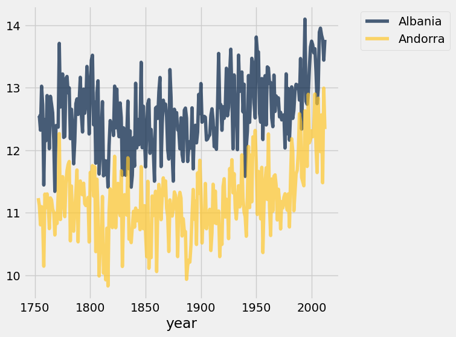

```python
yourCountries.plot('year')
```

**Question 1 continued:** In this markdown cell, explain an observation you see from the figure you generated.

**Question 2:** Let's visualize the change in temperature for the United States.

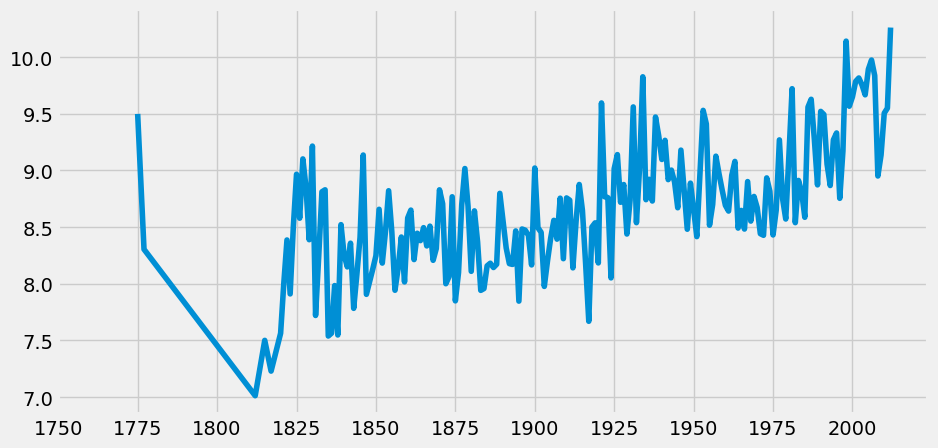

```python
us = pivotTable.where('United States', are.above(0))

plt.figure(figsize = (10, 5))
plt.plot(us['year'].astype(int), us['United States'])
plt.xticks(np.arange(1750, 2025, 25))
plt.show()
```

```python
check('tests/q2.py')
```

All tests passed!

**Question 3:** Null and alternative hypothesis. We may be curious whether globally temperatures are more likely to increase or decrease on average. Based on our preliminary figures and what we know about creating good hypotheses, set the null and alternative hypothesis below:

- Null hypothesis: Globally, temperatures are equally likely to increase or decrease on average in each time period.
- Alternative hypothesis: Globally, temperatures are more likely to increase on average in each time period.

To test the null hypothesis we're interested in identifying whether the temperature increased or decreased in each time period.  
Temperatures vary widely across countries and years, presumably due to the vast array of differences among the climates and human intervention. Rather than attempting to analyze the temperatures themselves, here we will restrict our analysis to whether or not temperatures increased or decreased over certain time spans. We will not concern ourselves with how much temperatures increased or decreased; only the direction of the changes - whether they increased or decreased.

The np.diff function takes an array of values and computes the differences between adjacent items of a list or array as such:

```
[item 1 - item 0 , item 2 - item 1 , item 3 - item 2, ...]
```

Instead, we may wish to compute the difference between items that are two positions apart. For example, given a 5-element array, we may want:

```
[item 2 - item 0 , item 3 - item 1 , item 4 - item 2]
```

The diff_n function below computes this result. Don't worry if the implementation uses unfamiliar features of Python, as long as you understand its behavior.

```python
def diff_n(values, n):
    return np.array(values)[n:] - np.array(values)[:-n]

diff_n(make_array(1, 10, 100, 1000, 10000), 2)
```

```
array([  99,  990, 9900])
```

**Question 4:** Implement the function changes that takes an array of temperatures for a country, ordered by increasing year. For all two-year periods (e.g., from 1960 to 1962), it computes and returns the number of increases minus the number of decreases.

For example, the array r = make_array(10, 7, 12, 9, 13, 9, 11) contains 3 increases (10 to 12, 7 to 9, and 12 to 13), 1 decrease (13 to 11), and 1 change that is neither an increase or decrease (9 to 9). Therefore, changes(r) would return 2, the difference between 3 increases and 1 decrease.

Hint: Consider using the `diff_n` function combined with boolean functions which use `np.count_non-zero` when array elements after using `diff_n` represent increases and separately when they represent decreases.

```python
def changes(array, years = 2):
    "Return the number of increases minus the number of decreases after two years."
    differences = diff_n(array, years)
    increase = np.count_nonzero(differences > 0)
    decrease = np.count_nonzero(differences < 0)
    return increase - decrease
```

```python
check('tests/q4.py')
```

All tests passed!

**Question 5:** Assign changes_by_country to a table with one row per country that has two columns: the Country name and the Temperature changes statistic computed across all years in our data set for that country. It may be useful to split this process into two steps. The final table's first 2 rows should look like this:

| country | avg changes |
| --- | --- |
| Afghanistan | 18 |
| Africa | 8 |

Hint: You can use a `group` method to apply your `changes` function to each column in the original data set while grouping on each country. See this example from Olympic data below:

```python
NORUSA = Table.read_table('NORUSA.csv')
NORUSA_NUMBERS = NORUSA.group(['Year','Team']) # Number of athletes per year
NORUSA_NUMBERS
```

| Year | Team | count |
| --- | --- | --- |
| 1924 | Norway | 72 |
| 1924 | United States | 41 |
| 1928 | Norway | 68 |
| 1928 | United States | 31 |
| 1932 | Norway | 66 |
| 1932 | United States | 54 |
| 1936 | Norway | 94 |
| 1936 | United States | 58 |
| 1948 | Norway | 126 |
| 1948 | United States | 81 |

... (34 rows omitted)

#### Now compute the increases - decreases for the winter olympics for each team

Apply this concept to create the table showing net change for each country.

```python
NORUSA_NUMBERS.group('Team',changes)
```

| Team | Year changes | count changes |
| --- | --- | --- |
| Norway | 20 | 10 |
| United States | 20 | 18 |

```python
country = temps.group('country',changes)
changes_by_country = country.select('country','avg changes')
changes_by_country
```

| country | avg changes |
| --- | --- |
| Afghanistan | 18 |
| Africa | 8 |
| Albania | -22 |
| Algeria | 9 |
| American Samoa | -3 |
| Andorra | 10 |
| Angola | -1 |
| Anguilla | 6 |
| Antigua And Barbuda | 0 |
| Argentina | -1 |

... (232 rows omitted)

```python
check('tests/q5.py')
```

All tests passed!

**Question 6:** Assign test_stat to the total increases minus the total decreases for all two-year periods and all countries in our data set. For example, if the temperature in Albania went up 23 times and fell 17 times, the total change for Albania would be 6. We want the total value for all the countries together.

```python
test_stat = sum(changes_by_country.column('avg changes'))
print('Total increases minus total decreases, across all countries and years:', test_stat)
```

```
Total increases minus total decreases, across all countries and years: 1140
```

```python
check('tests/q6.py')
```

All tests passed!

"More increases than decreases," one person exclaims, "Temperatures tend to go up across two-year periods. What dire times we live in."

"Not so fast," another person replies, "Even if temperatures just moved up and down uniformly at random, there would be some difference between the increases and decreases. There were a lot of countries and a lot of years, so there were many chances for changes to happen. If country temperature increase and decrease at random with equal probability, perhaps this difference was simply due to chance!"

Based on the null hypothesis above that country temperatures increase and decrease by chance, we can simulate our test statistic. Our test statistic should depend only on whether temperature increased or decreased, not on the size of any change. Thus we choose:

```
Test Statistic: The number of increases minus the number of decreases
```

The cell below samples increases and decreases at random from a uniform distribution 100 times. The final column of the resulting table gives the number of increases and decreases that resulted from sampling in this way. Using sample_from_distribution is faster than using sample followed by group to compute the same result.

```python
uniform = Table().with_columns(
    "Change", make_array('Increase', 'Decrease'),
    "Chance", make_array(0.5,        0.5))
uniform.sample_from_distribution('Chance', 100)
```

| Change | Chance | Chance sample |
| --- | --- | --- |
| Increase | 0.5 | 38 |
| Decrease | 0.5 | 62 |

**Question 7:** Complete the simulation below, which samples num_changes increases/decreases at random many times and forms an empirical distribution of your test statistic under the null hypothesis. Your job is to

- fill in the function simulate_under_null, which simulates a single sample under the null hypothesis, and
- fill in its argument when it's called below.

As a hint, num_changes should be approximately the number of countries times the number of time comparisons (you can find the number of year comparisons by using diff_n().

```python
def simulate_under_null(num_chances_to_change):
    """Simulates some number changing several times, with an equal
    chance to increase or decrease.  Returns the value of your
    test statistic for these simulated changes.

    num_chances_to_change is the number of times the number changes.
    """
    uniform = Table().with_columns(
        "Change", make_array('Increase', 'Decrease'),
        "Chance", make_array(0.5,        0.5))
    sample = uniform.sample_from_distribution('Chance', num_chances_to_change)
    num_increase = np.count_nonzero(np.random.choice(uniform.column('Change'),num_chances_to_change)=="Increase")
    num_decrease = np.count_nonzero(np.random.choice(uniform.column('Change'),num_chances_to_change)=="Decrease")
    return num_increase - num_decrease
```

```python
def empirical_distribution(tbl):
    num_year_comparisons = sum(diff_n(tbl.column('year'),1))
    num_changes = len(np.unique(tbl.column('country')))
    samples = make_array()
    for i in np.arange(10000):
        samples = np.append(samples, simulate_under_null(num_changes))
    Table().with_column('Test statistic under null', samples).hist(bins=np.arange(0, max(samples) + max(samples) * 0.1, 2))
    return samples
```

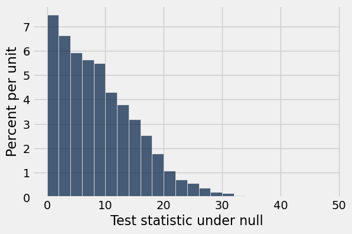

```python
samples = empirical_distribution(temps)
```

```python
check('tests/q7.py')
```

All tests passed!

**Question 8:** Complete the analysis as follows:

1. Compute a P-value. (Hint: you can use np.count_nonzero())
2. Using a 5% P-value cutoff, draw a conclusion about the null and alternative hypotheses.
3. Describe your findings using simple, non-technical language. What does your analysis tell you about temperatures changes over time? What can you claim about causation from your statistical analysis?

**P-value:** The p-value is 0.0

**Conclusion about the hypotheses:** The null hypothesis is rejected and the alternative hypothesis is favored.

**Findings:** There is a statistically significant trend that shows an increase in global temperature over the time. However, there may be other factors that influence temperature changes, such as natural climate cycles and other activities that contribute to climate change.

```python
pvalue = np.count_nonzero(samples>=test_stat)/len(samples)
pvalue
```

```
0.0
```

Some countries have implemented policies and laws to counteract climate change whereas others have not - we have a table that contains a boolean to indicate whether a country has any policies or laws to protect the earth and then has a number of policies and laws implemented in that country. We can test to see if those countries that have implemented policies to counteract climate change show any difference in changes in temperatures from those countries who have not implemented policies. A natural experiment happens when something other than experimental design applies a treatment to one group and not to another (control) group, and we have some hope that the treatment and control groups don't have any other systematic differences. This is likely not the case globally, but if we did believe that the countries didn't have other systematic differences, how would we set up the experiment.

Data Source: [Climate Change Laws of the World](https://climate-laws.org/legislation_and_policies)

**Question 9:** Describe this investigation in terms of an experiment. What population are we studying? What is the control group? What is the treatment group? What outcome are we measuring? Be precise!

*Write your answers below.*

- Population: Population is the countries around the world.
- Control: The control group is the number of countries that have not implemented policies to counteract climate change.
- Treatment: The treatment group is the number of countries that have implemented policies to counteract climate change.
- Outcome: The outcome we are measuring is the difference in temperature change between the treatment group and the control group, and observing the change in temperature over time.

```python
laws = Table.read_table('laws.csv')
laws
```

| country | haveLaws | numberLaws |
| --- | --- | --- |
| Afghanistan | True | 14 |
| Africa | False | 0 |
| Albania | True | 4 |
| Algeria | True | 14 |
| American Samoa | False | 0 |
| Andorra | True | 25 |
| Angola | True | 23 |
| Anguilla | False | 0 |
| Antigua And Barbuda | False | 0 |
| Argentina | True | 19 |

... (232 rows omitted)

1. Combine the temperature table and the laws table.
2. Set year_range to the correct time period.
3. Create two tables: one of countries that have climate change laws and one for countries that do not.

```python
temp_law = temps.join('country', laws)
year_range = temp_law.where('year', are.between(1990,2020))
haveLaws = year_range.where('haveLaws', True)
noLaws = year_range.where('haveLaws', False)
```

```python
check('tests/q10.py')
```

All tests passed!

**Question 11:** Calculate the test statistic for both subsets of countries: those that have implemented climate change laws and those that have not implemented these laws.

```python
laws_test_stat = sum(haveLaws.group('country',changes).select('country','avg changes').column('avg changes'))
laws_test_stat
```

```
199
```

```python
nolaws_test_stat = sum(noLaws.group('country',changes).select('country','avg changes').column('avg changes'))
nolaws_test_stat
```

```
61
```

```python
check('tests/q11.py')
```

All tests passed!

**Question 12:** Now using these tables from question 10 and the calculated test statistic from question 11, create an empirical distribution and calculate a p-value.

```
P-value for countries that have implemented policies to counteract climate change from 1990 to 2020 :0.0
```

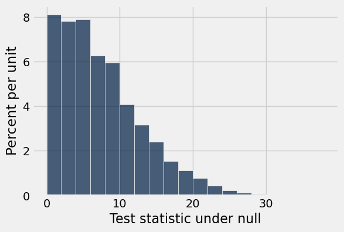

```python
haveLawsSamples = empirical_distribution(haveLaws)
lawsPvalue = np.count_nonzero(haveLawsSamples >= laws_test_stat) / len(haveLawsSamples)
print("P-value for countries that have implemented policies to counteract climate change from 1990 to 2020 :" + str(lawsPvalue))
```

```
P-value for countries that have NOT implemented policies to counteract climate change from 1990 to 2020 :0.0
```

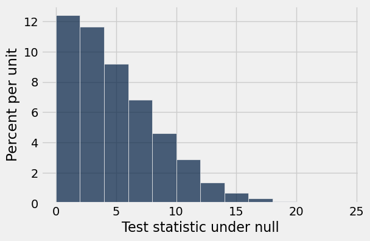

```python
noLawsSamples = empirical_distribution(noLaws)
nolawsPvalue = np.count_nonzero(noLawsSamples >= nolaws_test_stat) / len(noLawsSamples)
print("P-value for countries that have NOT implemented policies to counteract climate change from 1990 to 2020 :" + str(nolawsPvalue))
```

```python
# For your convenience, you can run this cell to run all the tests at once!
import glob
from gofer.ok import check
correct = 0
checks = [2, 4, 5, 6, 7, 10, 11]
total = len(checks)
for x in checks:
    print('Testing question {}: '.format(str(x)))
    g = check('tests/q{}.py'.format(str(x)))
    if g.grade == 1.0:
        print("Passed")
        correct += 1
    else:
        print('Failed')
        display(g)

print('Grade:  {}'.format(str(correct/total)))
```

```
Testing question 2:
Passed
Testing question 4:
Passed
Testing question 5:
Passed
Testing question 6:
Passed
Testing question 7:
Passed
Testing question 10:
Passed
Testing question 11:
Passed
Grade:  1.0
```